# VAR/VECM Models: Determining Causality between Unemployment and Retail Sales of Beer, Wine and Liquor

Owen Ragsdale

April 22, 2022

### *Executive Summary*

This white paper seeks insight into the causality and correlation between two variables, in this case the unemployment rate in the US and retail sales of beer, wine, and liquor from 1992 to February of 2022. Prior to the analysis the expected outcome was that as unemployment increased, we would see an increase in retail sales of alcoholic beverages. After adjusting the data and using a Vector Autoregression Model (VAR) we found that their is in fact two way causality between the two variables, even if the effect is small.

### *Introduction*

In the world of economics we classify goods in a variety of ways based on specific parameters. For example, economist would called a good that experiences an increase in demand based on an increase in consumers income, a normal good. A good that experiences less demand when income rises is considered an inferior good. The objective of this paper is to use VAR models to determine if unemployment, which is correlated with income, causes an change in retail sales of alcoholic beverages. We know through economic theory that in times of recession that individuals purchase more non-durable goods, items such as food, condiments, fuel, and other short life-spanned products. Another area of economic theory is elasticity, an economic concept that measures the change in quantity demanded over the change in price of the good. Alcohol is assumed to be an elastic good, meaning that consumers are sensitive to changes in price, this is different from a product such as cigarettes, where the product is highly addictive and therefore, consumers care far less about price.

To see the entire project and code please click the link below:

[link](https://owenrags.github.io/)

### *Data manipulation*

As mentioned in the previous paragraph the two variables that will be used in the VAR model are:

*Unemployment* - *UNRATE*

*Retail Sales: Beer, Wine, and Liquor Stores* - *MRTSSM4453USS*

Some important points regarding the data, are the units the data is measured in. *Unemployment rate* is measured in percent, reported monthly, and is seasonally adjusted. *Retail Sales: Beer, wine, and Liquor Stores* is measured in millions of dollars, reported monthly, and also seasonally adjusted.

Looking at the two plots of the variables gives us some insight into whether or not our variables appear to be coupled. From just a quick glance we can see that *retail sales* appear to be steadily increasing since 1992, but we do see a little bump in 2020 when COVID-19 begins. This may provide some evidence that unemployment does cause an increase in *retail sales: alcoholic beverages*.

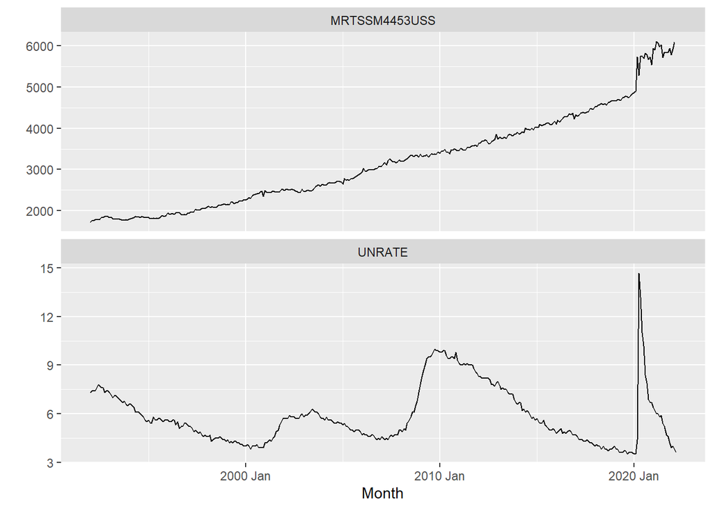

```r
X %>% ggplot(aes(x = Month, y = price)) +
  geom_line() +
  facet_wrap(vars(symbol), scales = "free_y", ncol=1) +
  labs(y = "")
```

```r
X %>%
  features(price, unitroot_ndiffs) %>%
  kable(format = "html", table.attr = "style='width:30%;' ") %>%
  kableExtra::kable_styling()
```

| symbol | ndiffs |
| --- | --- |
| MRTSSM4453USS | 2 |
| UNRATE | 0 |

### *Results of the VAR Model*

First and foremost, addressing the decision behind choosing a VAR model over other models. The variable unemployment is stationary, ruling out the use of VECM. However, the ordering of the variables mattered in terms of testing our expectation, being the effect in which unemployment had on Retail Sales.

The two tables below report the values output by what is known as the a Granger causality test. The statistic we are interested in is the value below the column labeled Pr(>F). In this case, lower values display both the variables, *unemployment* & *retail sales* are significant; however, the relationship shows a relationship far different than our expected outcome.

This first table suggest that our initial expectation of unemployment having an effect retail sales: alcoholic beverages is in fact accurate. This is substantiated by the low p-value of 0.0003306.

```r
grangertest(gMRTSSM4453USS ~ UNRATE, order=p, data = zh)
```

|  | Res.Df | Df | F | Pr(>F) |
| --- | --- | --- | --- | --- |
| 1 | 332 | NA | NA | NA |
| 2 | 341 | -9 | 3.537626 | 0.0003305774 |

This second table is the more interesting of the two. This table suggest that retail sales: alcoholic beverages, has an highly significant impact on unemployment. Although this is consistent with economic theory it was not the first primary expectation of outcome in this analysis.

```r
grangertest(UNRATE ~ gMRTSSM4453USS, order=p, data = zh)
```

|  | Res.Df | Df | F | Pr(>F) |
| --- | --- | --- | --- | --- |
| 1 | 332 | NA | NA | NA |
| 2 | 341 | -9 | 13.94176 | 4.688194e-19 |

In the second plot we ping retail sales of alcoholic beverages and we see a slight jump in unemployment, which again is consistent with our findings from the Granger test. Using the plot to discuss significance is miss leading because we are unable to determine the level of magnitude in regards to significance.

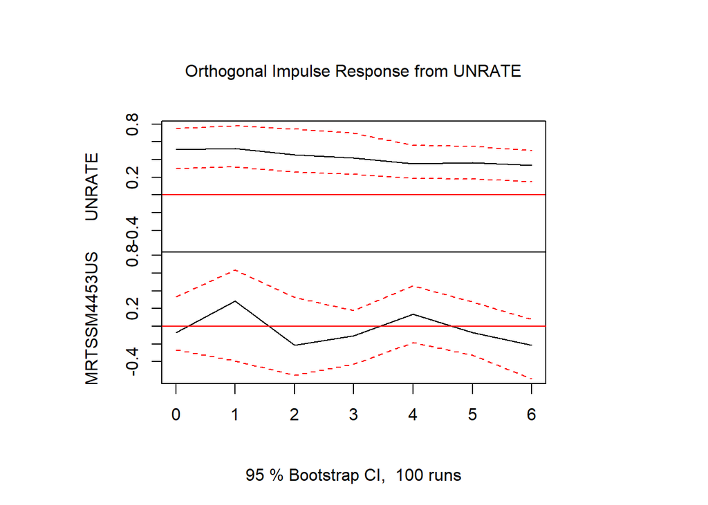

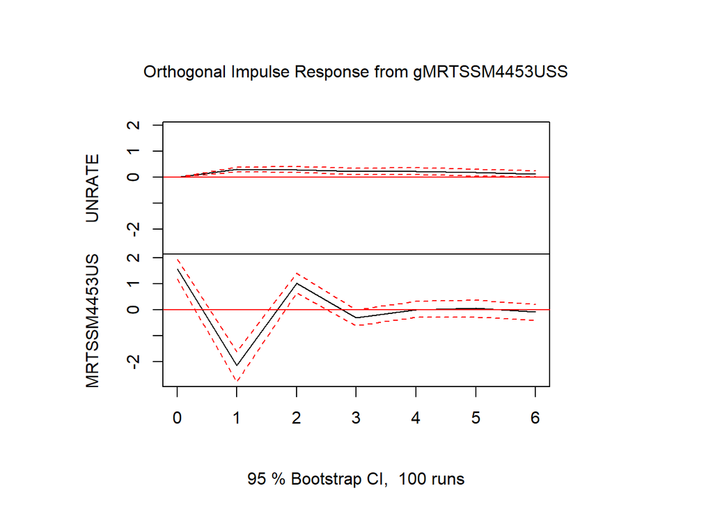

```r
plot(irf(var.Zdrink, n.ahead = 6, boot = TRUE))
```

Lastly, diving into the results of the forecast error variance decomposition. Both plots are fairly straight forward, most of the variance in unemployment is explained by unemployment and the same is true with retail sales of alcoholic beverages (gMRTSSM4453USS)

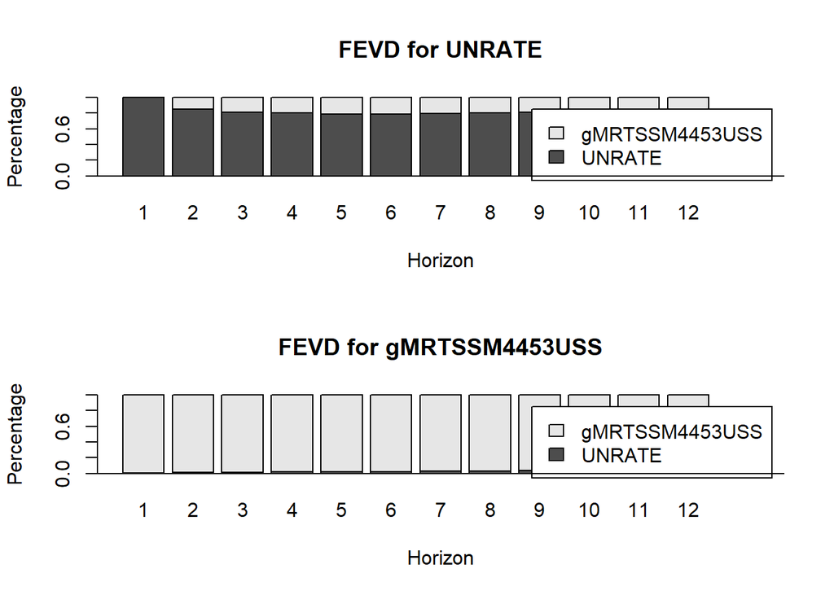

```r
plot(fevd(var.Zdrink, n.ahead = 12))
```

### *Conclusion*

Taking a step back from the analysis conducted above we can conclude the VAR model did in fact confirm the expected outcome that employment does cause retail sales: alcoholic beverages. However, it also gave us a more convincing argument that retail sales of alcoholic beverages has a larger impact on unemployment than previously expected. It is my belief that this finding suggest that retail sales as a whole, not just alcoholic beverages, have an impact on unemployment. This would be consistent with economic theory that would suggest that consumers stop purchasing as many goods when they become unemployed, due to lack of income. In order to confirm this we would need to gather new variables and more data to test this expectation.